# Week 06 Homework

Brian Ritz

May 25, 2015

Attached gas furnace dataset has the following:

Input gas rate - this is the independent variable

Output gas CO2 % - this is the dependent variable that needs to be forecast

Tasks:

Use linear regression model - plot the ACF - what can you conclude ? Use ARIMA (0,0,1) model for the residuals. Adjust the Input gas rate and Output CO2 % with the MA coefficient. Combine with the linear regression model. Plot the residuals. Use ARIMA (1,0,0) model for the residuals. Adjust the Input gas rate and Output CO2 % with the AR coefficient. Combine with the linear regression model. Plot the residuals. Use ARIMA (0,0,2) model for the residuals. Adjust the Input gas rate and Output CO2 % with the MA coefficient. Combine with the linear regression model. Plot the residuals. Use ARIMA (2,0,0) model for the residuals. Adjust the Input gas rate and Output CO2 % with the AR coefficient. Combine with the linear regression model. Plot the residuals. Use ARIMA (2,0,2) model for the residuals. Adjust the Input gas rate and Output CO2 % with the AR and MA coefficients. Combine with the linear regression model. Plot the residuals. Use fractional ARIMA model (aka ARFIMA) for the output gas CO2% - plot the residuals, acf and pacf plots of the model. You can use an R package like fracdiff Which ARIMA model gives the best result in terms of residuals being close to white noise ? The file arma_innovation.R contains an R function arma.innovation () that might be useful for adjusting the gas rate and CO2% given an ARMA model. You should study the code and the example in the file to try to understand what the function does and how it might help you.

```r
gas_dataset <- read.csv("Dataset.csv")
```

*Use the linear regression model, plot the acf, what can you conclude?*

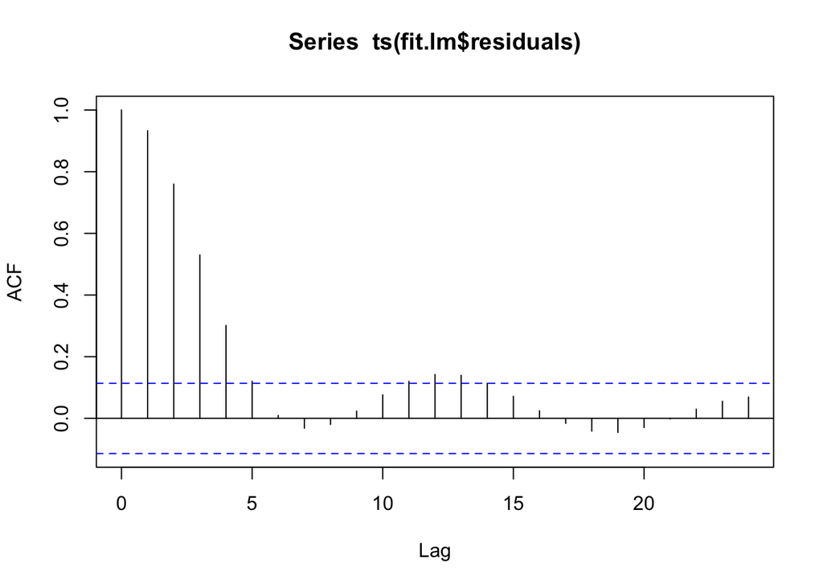

```r
fit.lm <- lm(gas_dataset$Outlet.gas.CO2.percentage~gas_dataset$Input.gas.rate)
acf(ts(fit.lm$residuals))
```

The autocorrelation function plot shows a pattern like a roller-coaster, with peaks at 12 and potentially 25. This particular pattern suggests there is autocorrelation in the errors.

*Use ARIMA (0,0,1) model for the residuals. Adjust the Input gas rate and Output CO2 % with the MA coefficient. Combine with the linear regression model. Plot the residuals.*

```r
resids<-ts(fit.lm$residuals)

# xreg is the external variables for the regression
print(arima.0.0.1<- arima(resids, order=c(0,0,1), xreg=gas_dataset$Input.gas.rate))
```

```
##
## Call:
## arima(x = resids, order = c(0, 0, 1), xreg = gas_dataset$Input.gas.rate)
##
## Coefficients:
##          ma1  intercept  gas_dataset$Input.gas.rate
##       0.9425     0.0114                      0.1034
## s.e.  0.0149     0.1698                      0.1539
##
## sigma^2 estimated as 2.264:  log likelihood = -542.05,  aic = 1092.09
```

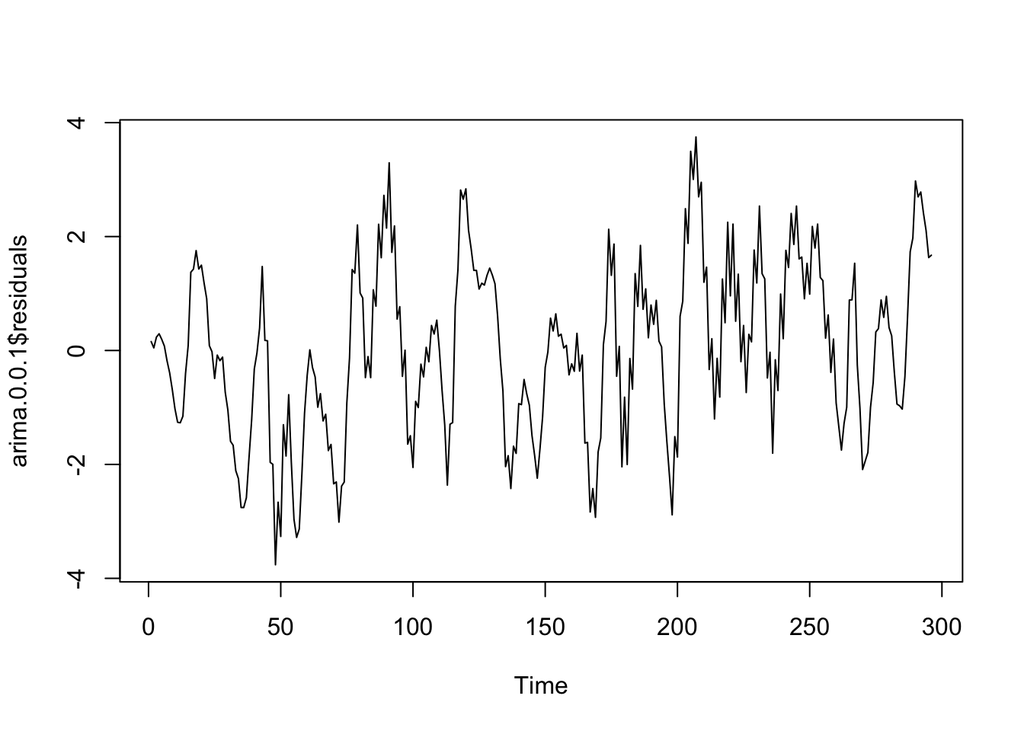

```r
plot(arima.0.0.1$residuals)
```

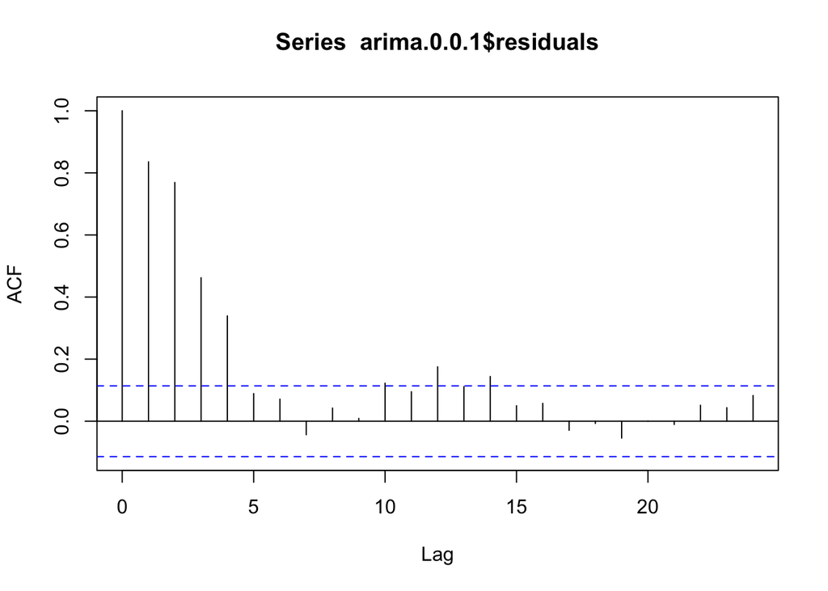

```r
acf(arima.0.0.1$residuals)
```

There still appears to be autocorrelation in the residuals–this is probably because we did not use an AR model to model the residuals.

*Use ARIMA (1,0,0) model for the residuals. Adjust the Input gas rate and Output CO2 % with the AR coefficient. Combine with the linear regression model. Plot the residuals.*

Use ARIMA (0,0,2) model for the residuals. Adjust the Input gas rate and Output CO2 % with the MA coefficient. Combine with the linear regression model. Plot the residuals.

Use ARIMA (2,0,0) model for the residuals. Adjust the Input gas rate and Output CO2 % with the AR coefficient. Combine with the linear regression model. Plot the residuals.

Use ARIMA (2,0,2) model for the residuals. Adjust the Input gas rate and Output CO2 % with the AR and MA coefficients. Combine with the linear regression model. Plot the residuals.